# Case Study III

```r
rm(summary)
```

The table shows each question’s summary of mean, median, minimum, maximum and standard deviation. The means range from 4.225974 ($Im22$) to 6.124675 ($Im14$). Only one of the questions, $Im22$, has a median of 4 while all others are either 5 or 6. The maximum of 7 is represented by the Likert-scale with 1 “does not apply at all” and 7 “does apply completely”. There are two instances ($Im7$ and $Im10$) where 2 is the minimum, insinuating that no one choose 1 for an answer in that scenario.

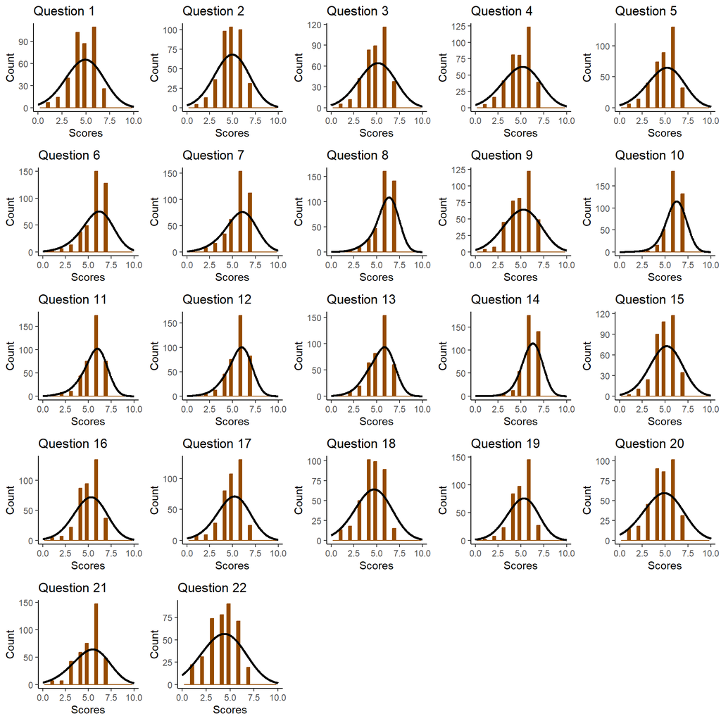

```r
# Create a list of plots
plots <- lapply(1:22, function(i) {
  # Store data in column.i as x
  x <- lafayette_122[,i]

ggplot(data.frame(x), aes(x)) +
    geom_histogram( fill = "#964B00", color = "#964B00", bandwidth = 2) +
    geom_density(aes(y = 0.85*..count..), color = "black", adjust = 4, size = 1) +
    ggtitle(paste("Question", i)) +
    xlab("Scores") +
    ylab("Count") +
    xlim(0, 10) +
    theme_classic()
})

# Display the plots with 9 columns
gridExtra::grid.arrange(grobs = plots, ncol = 5)
```

```r
stat.desc(lafayette_122, norm = TRUE)
```

```
##                        Im1           Im2           Im3           Im4
## nbr.val       3.850000e+02  3.850000e+02  3.850000e+02  3.850000e+02
## nbr.null      0.000000e+00  0.000000e+00  0.000000e+00  0.000000e+00
## nbr.na        0.000000e+00  0.000000e+00  0.000000e+00  0.000000e+00
## min           1.000000e+00  1.000000e+00  1.000000e+00  1.000000e+00
## max           7.000000e+00  7.000000e+00  7.000000e+00  7.000000e+00
## range         6.000000e+00  6.000000e+00  6.000000e+00  6.000000e+00
## sum           1.834000e+03  1.862000e+03  1.894000e+03  1.895000e+03
## median        5.000000e+00  5.000000e+00  5.000000e+00  5.000000e+00
## mean          4.763636e+00  4.836364e+00  4.919481e+00  4.922078e+00
## SE.mean       6.839073e-02  6.562485e-02  6.903125e-02  7.101909e-02
## CI.mean.0.95  1.344672e-01  1.290290e-01  1.357265e-01  1.396350e-01
## var           1.800758e+00  1.658049e+00  1.834646e+00  1.941829e+00
## std.dev       1.341923e+00  1.287653e+00  1.354491e+00  1.393495e+00
## coef.var      2.817014e-01  2.662440e-01  2.753321e-01  2.831112e-01
## skewness     -4.681989e-01 -4.023931e-01 -4.939958e-01 -5.293878e-01
## skew.2SE     -1.882512e+00 -1.617923e+00 -1.986235e+00 -2.128537e+00
## kurtosis     -1.579330e-01 -1.391745e-01 -2.595028e-01 -3.404488e-01
## kurt.2SE     -3.183135e-01 -2.805056e-01 -5.230270e-01 -6.861734e-01
## normtest.W    9.259798e-01  9.314219e-01  9.243739e-01  9.194560e-01
## normtest.p    7.272826e-13  2.648731e-12  5.028160e-13  1.676801e-13
##                        Im5           Im6           Im7           Im8
## nbr.val       3.850000e+02  3.850000e+02  3.850000e+02  3.850000e+02
## nbr.null      0.000000e+00  0.000000e+00  0.000000e+00  0.000000e+00
## nbr.na        0.000000e+00  0.000000e+00  0.000000e+00  0.000000e+00
## min           1.000000e+00  1.000000e+00  2.000000e+00  1.000000e+00
## max           7.000000e+00  7.000000e+00  7.000000e+00  7.000000e+00
## range         6.000000e+00  6.000000e+00  5.000000e+00  6.000000e+00
## sum           1.899000e+03  2.242000e+03  2.212000e+03  2.314000e+03
## median        5.000000e+00  6.000000e+00  6.000000e+00  6.000000e+00
## mean          4.932468e+00  5.823377e+00  5.745455e+00  6.010390e+00
## SE.mean       6.940943e-02  6.241822e-02  6.138367e-02  5.367693e-02
## CI.mean.0.95  1.364701e-01  1.227243e-01  1.206902e-01  1.055375e-01
## var           1.854802e+00  1.499973e+00  1.450663e+00  1.109267e+00
## std.dev       1.361911e+00  1.224734e+00  1.204435e+00  1.053217e+00
## coef.var      2.761116e-01  2.103133e-01  2.096326e-01  1.752328e-01
## skewness     -6.432465e-01 -1.264973e+00 -1.091544e+00 -1.367905e+00
## skew.2SE     -2.586335e+00 -5.086144e+00 -4.388828e+00 -5.500008e+00
## kurtosis     -1.026973e-01  1.465073e+00  8.215243e-01  2.233537e+00
## kurt.2SE     -2.069860e-01  2.952849e+00  1.655779e+00  4.501686e+00
```

[output cut: 71 more lines]

```
## range         6.000000e+00  6.000000e+00
## sum           1.976000e+03  1.627000e+03
## median        6.000000e+00  4.000000e+00
## mean          5.132468e+00  4.225974e+00
## SE.mean       7.047325e-02  7.894308e-02
## CI.mean.0.95  1.385617e-01  1.552148e-01
## var           1.912094e+00  2.399324e+00
## std.dev       1.382785e+00  1.548975e+00
## coef.var      2.694191e-01  3.665368e-01
## skewness     -7.796933e-01 -2.614108e-01
## skew.2SE     -3.134953e+00 -1.051068e+00
## kurtosis      8.903519e-02 -6.665224e-01
## kurt.2SE      1.794501e-01 -1.343373e+00
## normtest.W    8.916870e-01  9.435376e-01
## normtest.p    7.142346e-16  6.148181e-11
```

The histograms provide the reader a clear understanding about the distribution of the each survey question. There are several observations that help depict how customers responded:

1. A majority of the questions have most responses between 4 to 6.
2. Out of the 22 distributions, there are several that appear to be skewed. This will be further analyzed below.

Since there are assumptions of normality that need to be fulfilled, it is critical to understand the skewness and kurtosis of each column. To be normal, a data set needs to be symmetric and have a bell-shaped curve.

Skewness range: A negative skew means that the tail of the distribution is longer on the left side. Therefore, most of the data is concentrated on the right side of the histogram. The opposite can be said about positive skewness. For all 22 questions, they all appear to have a negative skew. The most prominent skewed distributed can be seen in $Im14$ and $Im8$. Based on prior class discussion though, the skewness is considered relatively small due to the context of the data.

Kurtosis range: The closer the value is to zero, the more flat the distribution relative to a normality. There are several questions where their values are within an absolute value of 1.6, which would insinuate that the distributions are more flat than other distributions and possibly non-normal. Since these values are around +/- 1.6 or above/below, we can conclude that they are not flat, but have a bell-shape. Anything above zero would have a “leptokurtic” distribution, peaked higher than the expected normal distribution. If the value is negative, it follows a “platykurtic” distribution, indicating that it is flatter. This can occur when the data is more spread out and has a lower concentration around the mean.  
- **Resource**: [1, see end of report]

# 2 Part II - Exploratory Factor Analyses

## 2.1 Correlation Matrix

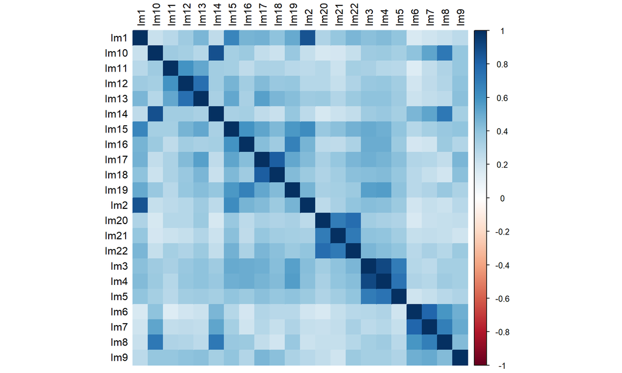

```r
corr_lafayette_122 <- cor(lafayette_122)

corrplot(corr_lafayette_122, tl.col = "black", number.cex = 0.8, method = 'color', order = 'alphabet')
```

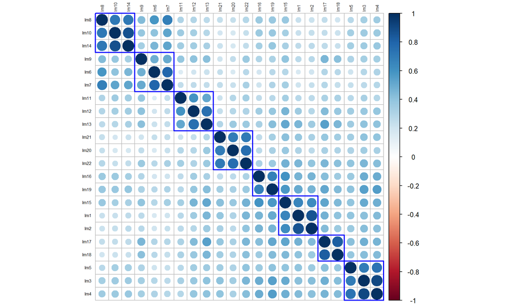

```r
corrplot(corr_lafayette_122, tl.col = "black", number.cex = 0.8, order = "hclust", tl.cex = 0.5, addrect = 8, rect.col = 'blue')
```

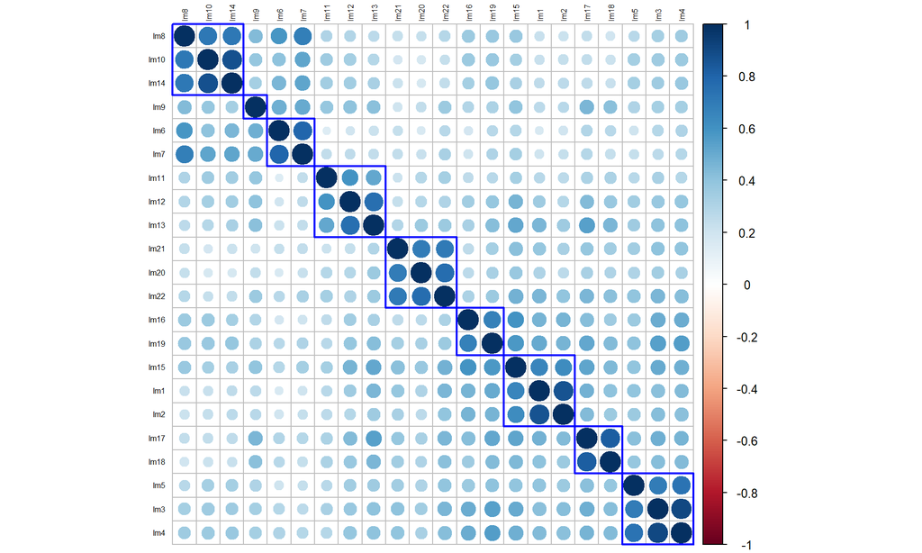

```r
# Resource [1]

corrplot(corr_lafayette_122, tl.col = "black", number.cex = 0.8, order = "hclust", tl.cex = 0.5, addrect = 9, rect.col = 'blue')
```

```r
# Resource [1]
```

A primary goal in factor analysis is to ensure that the variables are suitable to obtain distinct dimensions in order to reduce the number of items to explain and interpret the results. The correlation matrix shows that some variables are highly correlated with one another while others have almost no relationship. Here are several examples:

- $Im3$ and $Im4$ have the highest correlation at 91%, with $Im2$ and $Im1$ at 87%.
- There are an additional five relationships that have a correlation between 73% and 85%, indicated by the larger and darker blue squares.

There are two other correlation matrices with blue boxes around the questions that need to be considered. These boxes indicate how many possible factors will be used. In the first one, a hypothetical 8-factor solution shows that there are eight groupings with at least two questions each. In the second correlation plot, 9-factors represented. Here, we see the box that previously had $Im9$, $Im6$, and $Im7$, separate into two boxes. $Im9$ is now a standalone question within its own factor, and this is possibly due to not having a high loading in any of the other factors. This could be problematic since that question has no relation with any other survey questions. $Im9$ will be on the preliminary watch list.

**Resource** [1] https://cran.r-project.org/web/packages/corrplot/vignettes/corrplot-intro.html\

## 2.2 Barlett’s Test of Sphericity

```r
bart_spher(lafayette_122)
```

```
##  Bartlett's Test of Sphericity
##
## Call: bart_spher(x = lafayette_122)
##
##      X2 = 6451.238
##      df = 231
## p-value < 2.22e-16
```

The Bartlett-Test (test of sphericity) ‘tests the hypothesis that the sample originates from a population, where are variables are uncorrelated’. The main assumption is that the variables in a population are normally distributed. Bartlett-Test of Sphericity is highly significant. The p-value is very small,the $H_0$ that all correlations between IVs are 0 can be rejected ($H_0$: correlation matrix = identity matrix). Additional tests like the Kaiser-Meyer-Olkin (KMO) or Measure of Sampling Adequacy (MSA) can be utilized and may be more appropriate.

## 2.3 Kaiser-Meyer-Olkin Criterion

```r
KMO_Test <- KMOS(lafayette_122)
KMO_Test
```

```
##
## Kaiser-Meyer-Olkin Statistics
##
## Call: KMOS(x = lafayette_122)
##
## Measures of Sampling Adequacy (MSA):
##       Im1       Im2       Im3       Im4       Im5       Im6       Im7       Im8
## 0.8244624 0.8224640 0.8640362 0.8542604 0.9546668 0.8224827 0.8448231 0.9300079
##       Im9      Im10      Im11      Im12      Im13      Im14      Im15      Im16
## 0.9380091 0.8285789 0.9113882 0.8789413 0.8722220 0.8267452 0.9647563 0.9092200
##      Im17      Im18      Im19      Im20      Im21      Im22
## 0.8644991 0.8550678 0.9400714 0.8266391 0.9149654 0.8793157
##
## KMO-Criterion: 0.8770975
```

The KMO test measures sampling adequacy (MSA) by taking the ‘ratio of the sum of squared correlations to the sum of squared correlations plus the sum of squared partial correlations’. If the value is greater than 0.6, the data can be reduced to less dimensions by meeting the required threshold. For this factor analysis, it surpasses that requirement at 0.88, which means that the data is a good fit for factor analysis since it has a value closer to 1.

## 2.4 Measures of Sampling Adequacy (MSA)

```r
sort(KMO_Test$MSA)
```

```
##       Im2       Im6       Im1      Im20      Im14      Im10       Im7       Im4
## 0.8224640 0.8224827 0.8244624 0.8266391 0.8267452 0.8285789 0.8448231 0.8542604
##      Im18       Im3      Im17      Im13      Im12      Im22      Im16      Im11
## 0.8550678 0.8640362 0.8644991 0.8722220 0.8789413 0.8793157 0.9092200 0.9113882
##      Im21       Im8       Im9      Im19       Im5      Im15
## 0.9149654 0.9300079 0.9380091 0.9400714 0.9546668 0.9647563
```

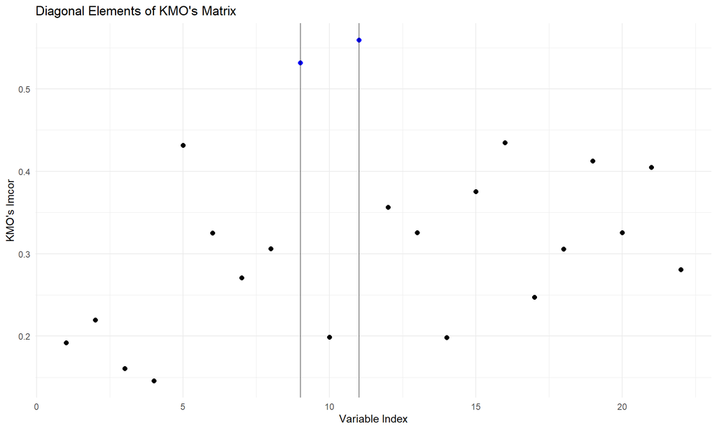

```r
# Compute the Kaiser-Meyer-Olkin (KMO) measure for a dataset with 133 variables
kmo_results <- KMO(lafayette_122)

# Create a data frame with the diagonal values and their indices
df <- data.frame(values = diag(kmo_results$ImCov), index = 1:length(diag(kmo_results$ImCov)))

# Plot the diagonal values using ggplot2
ggplot(df, aes(x = index, y = values)) +
  geom_point(size = 2, color = ifelse(df$values > 0.5, "blue", "black")) +
  geom_vline(xintercept = 9,lwd = .05,color = "black") +
  geom_vline(xintercept = 11,lwd = .05,color = "black") +
  scale_x_continuous(name = "Variable Index") +
  scale_y_continuous(name = "KMO's Imcor") +
  ggtitle("Diagonal Elements of KMO's Matrix") +
  theme_minimal()
```

Lowest value in Anti-Image correlation is for $Im2$ (“Assortment Variety”), but it will most likely not be on the watch list since it is not considered an outlier within these questions. This is due to the value falling in line with $Im6$ and has a small gap to the second and third questions.

The Anti-Image Correlation ‘measure the sampling adequacy for each individual variable’. From using this type of matrix, ‘items that do not correlate with any of the factors can be easily identified. If a value is below 0.5, the corresponding variable should be removed from the analysis’. As seen above, all elements are above that threshold.

Additionally, it is interesting to look at the MSA diagonals because it relates to how well those factors/dimensions have been covered throughout the survey questions. Both $Im9$ and $Im11$ are a bit higher (above 0.5) compared to every other question according to the blue dots. Therefore, we add $Im11$ to the watch list with $Im9$.

## 2.5 Factor Analysis - All factors

```r
# Run factor analysis with no rotation (Anastasia's Code: Case Study II)
fa_0 <- fa(lafayette_122, nfactors = ncol(lafayette_122), rotate = "none")

# Look at communalities
sort(fa_0$communalities)
```

```
##      Im11       Im9       Im5      Im21      Im19      Im15      Im16       Im8
## 0.6017430 0.6131069 0.6413666 0.7117001 0.7290241 0.7485245 0.7604446 0.7936975
##      Im12      Im18      Im13      Im20      Im22       Im6       Im7      Im10
## 0.8132541 0.8294448 0.8417272 0.8564198 0.8745729 0.8773807 0.8937851 0.9167615
##       Im2       Im3      Im17       Im4      Im14       Im1
## 0.9264859 0.9307854 0.9352630 0.9664673 0.9711077 0.9761381
```

All of the communalities appear to be aligned with each other in terms of the gap difference between each question. Please note that $Im9$ and $Im11$ have the smallest communality value but continue to meet the threshold of 0.6. Question 11 in particular is very close to 0.6, maybe too close for comfort. Therefore, no variables would be added to the watch list, but $Im11$ should be remembered.

The first factor analysis includes all images.

```r
# Run factor analysis
FA_PAF <- fa(lafayette_122,
              nfactors = ncol(lafayette_122),
              rotate = "none")

# Data frame with eigenvalues and variance
total_var_explained_paf <- data.frame(
  Factor_n = as.factor(1:length(FA_PAF$e.values)),
  Eigenvalue = FA_PAF$e.values,
  Variance = FA_PAF$e.values/(ncol(lafayette_122))*100,
  Cum_var = cumsum(FA_PAF$e.values/ncol(lafayette_122))
  )
total_var_explained_paf
```

```
##    Factor_n Eigenvalue   Variance   Cum_var
## 1         1 8.97758636 40.8072107 0.4080721
## 2         2 2.46726381 11.2148355 0.5202205
## 3         3 1.56195916  7.0998144 0.5912186
## 4         4 1.45683885  6.6219948 0.6574386
## 5         5 1.24785174  5.6720533 0.7141591
## 6         6 1.14733750  5.2151705 0.7663108
## 7         7 0.81009930  3.6822696 0.8031335
## 8         8 0.71161301  3.2346046 0.8354795
## 9         9 0.56785521  2.5811600 0.8612911
## 10       10 0.45684420  2.0765645 0.8820568
## 11       11 0.36139965  1.6427257 0.8984840
## 12       12 0.33234747  1.5106703 0.9135907
## 13       13 0.29499718  1.3408963 0.9269997
## 14       14 0.28351700  1.2887137 0.9398868
## 15       15 0.24936387  1.1334721 0.9512216
## 16       16 0.22811058  1.0368663 0.9615902
## 17       17 0.20225224  0.9193284 0.9707835
## 18       18 0.18624143  0.8465520 0.9792490
## 19       19 0.15737216  0.7153280 0.9864023
## 20       20 0.11623773  0.5283533 0.9916858
## 21       21 0.10167221  0.4621464 0.9963073
## 22       22 0.08123935  0.3692698 1.0000000
```

All 22 images are included within the factor analysis. The first factor has an eigenvalue of 8.98, which indicates that it can explain about 40.8% of the overall variance. In total, there are six factors that are above the Kaiser criterion of 1. Those factors explain 76.6% of the overall variance. Since the the seventh factor is not close enough to 1, it would not be considered at the moment.

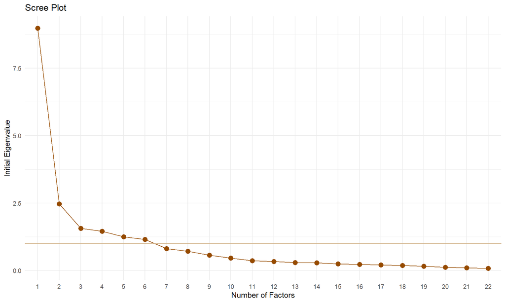

```r
# Scree plot (Anastasia's Code: Case Study II)
ggplot(total_var_explained_paf, aes(x = Factor_n, y = Eigenvalue, group = 1)) +
  geom_point(size = 3, color = "#964B00") +
  geom_line(color = "#964B00") +
  xlab("Number of Factors") +
  ylab("Initial Eigenvalue") +
  labs( title = "Scree Plot") +
  geom_abline(intercept = 1, slope = 0, color = "#D2B48C") +
  theme_minimal()
```

The graph above shows a screeplot, which is a ‘graphical representation of eigenvalues by ordering them according to their size’. There are two ways to analyze this chart, by the numerical representation of the eigenvlaue or subjectively. The analyst shoul retain the eigenvalues above the break at 1 or elbow of the curve. To use the subjective rule, visualizing the elbow can be difficult as multiple interpretations can occur. If we had to guess, it would most likely be 8-factors or 9-factors. Therefore, a more concrete approach is to look at the Kaiser criterion. The main rule to follow is that only eigenvalues greater than 1 should be extracted. If that eigenvalue is less than 1, this means that the factor ‘contributes less than a single variable in explaining total variance’. It is seen within the screeplot that there is an 6-factor solution by the points that are on or above the tan line indicating which eigenvalues are above that threshold.

The second factor analysis will remove question 9 since it has appeared on the watch list.

```r
# Run factor analysis
FA_PAF_9 <- fa(lafayette_122_9,
              nfactors = ncol(lafayette_122_9),
              rotate = "none")

# Data frame with eigenvalues and variance
total_var_explained_paf_9 <- data.frame(
  Factor_n = as.factor(1:length(FA_PAF_9$e.values)),
  Eigenvalue = FA_PAF_9$e.values,
  Variance = FA_PAF_9$e.values/(ncol(lafayette_122_9))*100,
  Cum_var = cumsum(FA_PAF_9$e.values/ncol(lafayette_122_9))
  )
total_var_explained_paf_9
```

```
##    Factor_n Eigenvalue   Variance   Cum_var
## 1         1 8.64255949 41.1550452 0.4115505
## 2         2 2.42094780 11.5283229 0.5268337
## 3         3 1.56133398  7.4349237 0.6011829
## 4         4 1.40988187  6.7137232 0.6683201
## 5         5 1.24512657  5.9291741 0.7276119
## 6         6 1.08272692  5.1558425 0.7791703
## 7         7 0.80003002  3.8096668 0.8172670
## 8         8 0.69784002  3.3230477 0.8504975
## 9         9 0.50656792  2.4122282 0.8746197
## 10       10 0.37560660  1.7886029 0.8925058
## 11       11 0.34236032  1.6302872 0.9088086
## 12       12 0.30149069  1.4356700 0.9231653
## 13       13 0.28399397  1.3523522 0.9366889
## 14       14 0.25094003  1.1949525 0.9486384
## 15       15 0.22842484  1.0877373 0.9595158
## 16       16 0.20303273  0.9668225 0.9691840
## 17       17 0.18639876  0.8876131 0.9780601
## 18       18 0.15743350  0.7496833 0.9855570
## 19       19 0.11706472  0.5574510 0.9911315
## 20       20 0.10458792  0.4980377 0.9961118
## 21       21 0.08165136  0.3888160 1.0000000
```

Without images 9, the first factor has an eigenvalue of 8.64, explaining 41.1% of variance. With the 6-factor solution proposed by the eigenvalues exceeding 1, the total variance would be 77.9%, which is slightly higher than the model with all images.

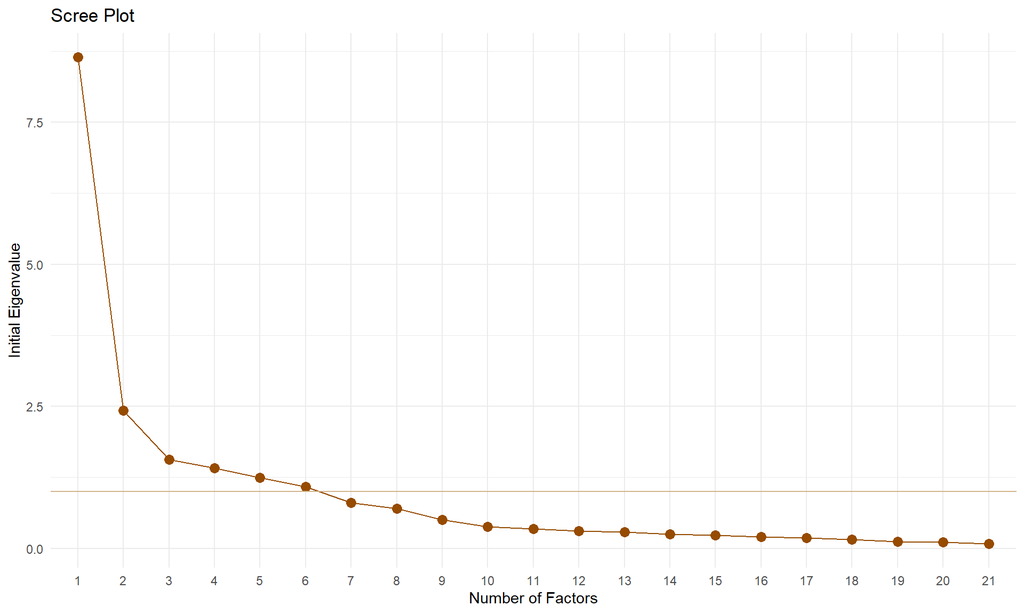

```r
# Scree plot (Anastasia's Code: Case Study II)
ggplot(total_var_explained_paf_9, aes(x = Factor_n, y = Eigenvalue, group = 1)) +
  geom_point(size = 3, color = "#964B00") +
  geom_line(color = "#964B00") +
  xlab("Number of Factors") +
  ylab("Initial Eigenvalue") +
  labs( title = "Scree Plot") +
  geom_abline(intercept = 1, slope = 0, color = "#D2B48C") +
  theme_minimal()
```

With only 9 removed, the Kaiser criterion chooses a 6-factor solution while the elbow method leans more towards 8-factors. At this point, we will also consider removing question 11, and a combination of the two excluded prior to grouping the questions.

The third factor analysis will remove question 11 since it has appeared on the watch list from the high MSA diagonal and very close to the communality value of 0.6.

```r
# Run factor analysis
FA_PAF_11 <- fa(lafayette_122_11,
              nfactors = ncol(lafayette_122_11),
              rotate = "none")

# Data frame with eigenvalues and variance
total_var_explained_paf_11 <- data.frame(
  Factor_n = as.factor(1:length(FA_PAF_11$e.values)),
  Eigenvalue = FA_PAF_11$e.values,
  Variance = FA_PAF_11$e.values/(ncol(lafayette_122_11))*100,
  Cum_var = cumsum(FA_PAF_11$e.values/ncol(lafayette_122_11))
  )
total_var_explained_paf_11
```

```
##    Factor_n Eigenvalue   Variance   Cum_var
## 1         1  8.7147163 41.4986491 0.4149865
## 2         2  2.4664301 11.7449052 0.5324355
## 3         3  1.5596820  7.4270570 0.6067061
## 4         4  1.3365089  6.3643283 0.6703494
## 5         5  1.2178662  5.7993630 0.7283430
## 6         6  1.0435787  4.9694223 0.7780372
## 7         7  0.7990439  3.8049708 0.8160870
## 8         8  0.7115962  3.3885534 0.8499725
## 9         9  0.5319339  2.5330184 0.8753027
## 10       10  0.3638585  1.7326594 0.8926293
## 11       11  0.3325915  1.5837692 0.9084670
## 12       12  0.2977796  1.4179981 0.9226469
## 13       13  0.2867493  1.3654728 0.9363017
## 14       14  0.2495872  1.1885103 0.9481868
## 15       15  0.2383457  1.1349794 0.9595366
## 16       16  0.2027971  0.9657003 0.9691936
## 17       17  0.1866211  0.8886720 0.9780803
## 18       18  0.1576935  0.7509214 0.9855895
## 19       19  0.1174775  0.5594168 0.9911837
## 20       20  0.1032567  0.4916986 0.9961007
## 21       21  0.0818862  0.3899343 1.0000000
```

The fourth factor analysis will remove questions 9 and 11.

```r
# Run factor analysis
FA_PAF_911 <- fa(lafayette_122_911,
              nfactors = ncol(lafayette_122_911),
              rotate = "none")

# Data frame with eigenvalues and variance
total_var_explained_paf_911 <- data.frame(
  Factor_n = as.factor(1:length(FA_PAF_911$e.values)),
  Eigenvalue = FA_PAF_911$e.values,
  Variance = FA_PAF_911$e.values/(ncol(lafayette_122_911))*100,
  Cum_var = cumsum(FA_PAF_911$e.values/ncol(lafayette_122_911))
  )
total_var_explained_paf_911
```

```
##    Factor_n Eigenvalue   Variance   Cum_var
## 1         1 8.38683697 41.9341848 0.4193418
## 2         2 2.42037317 12.1018659 0.5403605
## 3         3 1.55759518  7.7879759 0.6182403
## 4         4 1.27394452  6.3697226 0.6819375
## 5         5 1.19041155  5.9520577 0.7414581
## 6         6 1.01743870  5.0871935 0.7923300
## 7         7 0.79165335  3.9582667 0.8319127
## 8         8 0.69746085  3.4873042 0.8667857
## 9         9 0.37643666  1.8821833 0.8856075
## 10       10 0.34557021  1.7278511 0.9028861
## 11       11 0.30971750  1.5485875 0.9183719
## 12       12 0.28698464  1.4349232 0.9327212
## 13       13 0.25096150  1.2548075 0.9452692
## 14       14 0.23942415  1.1971207 0.9572404
## 15       15 0.20345710  1.0172855 0.9674133
## 16       16 0.18686691  0.9343346 0.9767566
## 17       17 0.15772046  0.7886023 0.9846427
## 18       18 0.11782012  0.5891006 0.9905337
## 19       19 0.10706980  0.5353490 0.9958872
## 20       20 0.08225667  0.4112833 1.0000000
```

Out of the three factor analyses, removing 9 and 11 together seemed to have the highest cumulative variance at 79.2%. Therefore, we will continue this analysis with different numbers of factors with or without at least these two questions. There could be a possibility that there are more questions that may have to be removed.

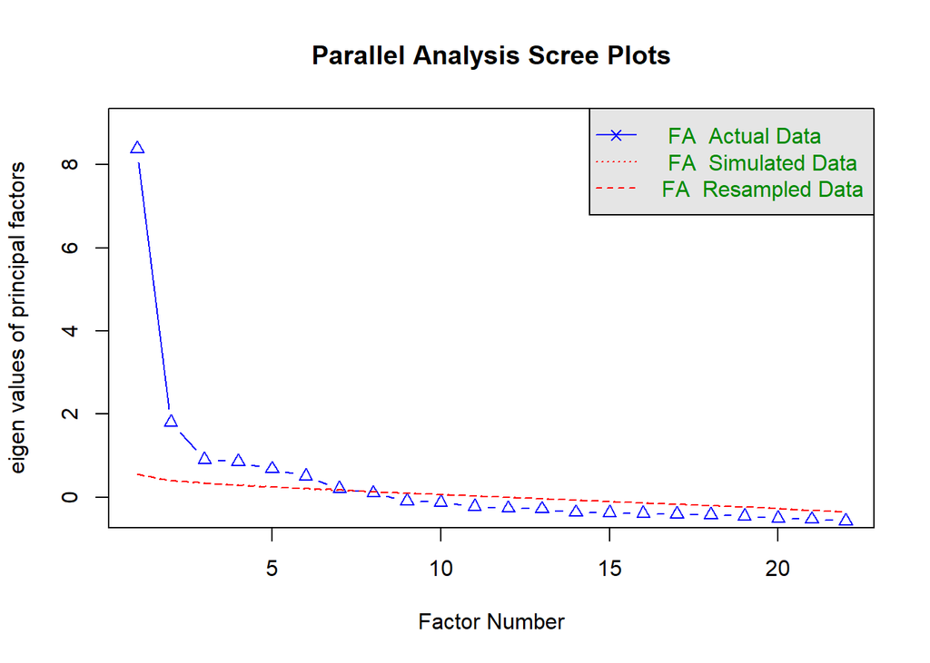

```
## Parallel analysis suggests that the number of factors =  7  and the number of components =  NA
```

```r
#parallel scree plots
fa.parallel(lafayette_122,fa = 'fa',fm = 'pa')
```

```r
result = fa(r = lafayette_122, nfactors = 8, fm = 'pa', rotate = 'varimax')
result$Vaccounted
```

```
##                             PA1       PA3       PA4       PA7        PA2
## SS loadings           2.4771352 2.3449759 2.2623329 2.2599278 2.16155740
## Proportion Var        0.1125971 0.1065898 0.1028333 0.1027240 0.09825261
## Cumulative Var        0.1125971 0.2191869 0.3220202 0.4247442 0.52299678
## Proportion Explained  0.1489685 0.1410208 0.1360509 0.1359062 0.12999048
## Cumulative Proportion 0.1489685 0.2899893 0.4260402 0.5619464 0.69193688
##                              PA5        PA6        PA8
## SS loadings           2.10725169 1.66052770 1.35487358
## Proportion Var        0.09578417 0.07547853 0.06158516
## Cumulative Var        0.61878095 0.69425948 0.75584464
## Proportion Explained  0.12672468 0.09985985 0.08147860
## Cumulative Proportion 0.81866155 0.91852140 1.00000000
```

The parallel plot review how many factors are estimated to be the best solution. The recommended number of factors is 7. If we strictly look at the eigenvalues though, there would be only two factors above 1.

To obtain the best model, we will test several scenarios with different factors to see which ones have the optimal metrics to choose how many factors should be used. Here is a quick summary of the six elements below:

- The “BIC” statistic represents the Bayesian information criterion.
- The “crms” statistic is a modified version of rms that accounts for degrees of freedom.
- The factor model’s ability to reproduce the correlation matrix is assessed by the “fit” statistic.
- The “objective” value is obtained by minimizing a function using maximum likelihood procedure.
- The “rms” metric measures the sum of squared off-diagonal residuals divided by the degrees of freedom.
- The “TLI” index calculates the Tucker Lewis Index of factoring reliability.

## 2.6 Principal Axis Factoring Possiblities

```r
# we initiate and empty dataframe which will record our criteria values
fit_df <- matrix(nrow = 10, ncol = 6)
colnames(fit_df) <- c("fit", "objective", "rms", "crms", "TLI", "BIC")
fit_df <- as.data.frame(fit_df)

# we compute the factor analysis for nfactors between 1 and 13 and record criteria results in fit_df
for (i in 1:10) {
  FA <- fa(lafayette_122, nfactors = i, rotate = "varimax", fm = "pa")
  fit_df[i, 1] <- FA$fit
  fit_df[i, 2] <- FA$objective
  fit_df[i, 3] <- FA$rms
  fit_df[i, 4] <- FA$crms
  fit_df[i, 5] <- FA$TLI
  fit_df[i, 6] <- FA$BIC
}

rm(i, FA)
# Resource [2]
```

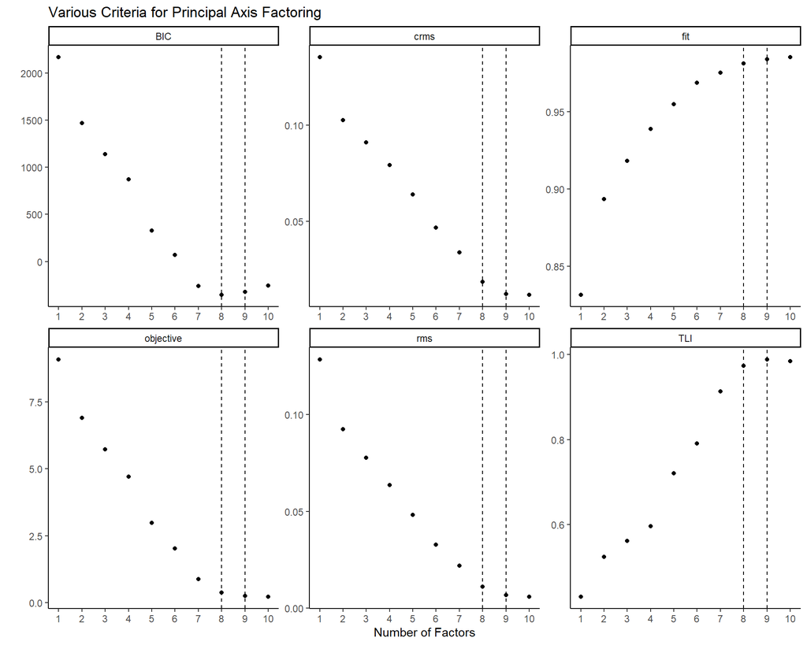

```r
fit_df %>% gather() %>%
  ggplot(aes(x = rep(1:10, ncol(fit_df)), y = value)) +
  facet_wrap(~ key, scales = "free") +
  geom_point() +
  theme_classic() +
  scale_x_continuous(breaks = seq(1, 10, 1)) +
  geom_vline(xintercept = 8, linetype = "dashed") +
  geom_vline(xintercept = 9, linetype = "dashed") +
  labs(title = "Various Criteria for Principal Axis Factoring",
       x = "Number of Factors",
       y = "")
```

```r
# Resource [2]
```

An ideal model exhibits high values of `fit` and `TLI`, while all other metrics should be low. When considering this criteria, it would appear that either a 8 or 9 factor solution is better than what what proposed by the Kaiser criteria at 6-factors or even with the parallel analysis with 7 factors. Therefore, this analysis will only consider 8 and 9 factor options with a combination of removing $Im9$ and $Im11$.

**Resource** [2] Lucia Camenisch helped with this code.

There are three combinations of excluding or including the two questions on the watch list. One more will only have $Im9$ removed while the next only excludes $Im11$. The third model will remove both $Im9$ and $Im11$ since it proved to explain the most variability earlier.

```r
FA_PAF_89 <- fa(lafayette_122_9, fm = "pa", rotate = "varimax", nfactors = 8)# 8 factors without 9
FA_PAF_811 <- fa(lafayette_122_11, fm = "pa", rotate = "varimax", nfactors = 8)# 8 factors without 11
FA_PAF_8911 <- fa(lafayette_122_911, fm = "pa", rotate = "varimax", nfactors = 8) # 8 factors without 9 & 11

FA_RAF_99 <- fa(lafayette_122_9, fm = "pa", rotate = "varimax", nfactors = 9) # 9 factors without 9
FA_RAF_911 <- fa(lafayette_122_11, fm = "pa", rotate = "varimax", nfactors = 9) # 9 factors without 11
FA_PAF_9911 <- fa(lafayette_122_911, fm = "pa", rotate = "varimax", nfactors = 9) # 9 factors without 9 & 11
```

## 2.7 Factor Summary

```r
# Create a data frame with three columns
my_table <- data.frame(
  Model = c("8-factor w/o 9", "8-factor w/o 11", "8-factor w/o 9_11", "9-factor w/o 9", "9-factor w/o 11", "9-factor w/o 9_11"),
  BIC = c(-311.3, -308.2, -272.3, -267.9, -273.06, -217.8),
  fit = c(0.9835, 0.9839, 0.9864, 0.9862, 0.9863, 0.9875),
  rms = c(0.008503, 0.009291, 0.006371, 0.005813, 0.005444, 0.00506),
  TIL = c(0.982, 0.981, 0.991, 0.991, 0.994, 0.993)
  )

# Print the table
print(my_table)
```

```
##               Model     BIC    fit      rms   TIL
## 1    8-factor w/o 9 -311.30 0.9835 0.008503 0.982
## 2   8-factor w/o 11 -308.20 0.9839 0.009291 0.981
## 3 8-factor w/o 9_11 -272.30 0.9864 0.006371 0.991
## 4    9-factor w/o 9 -267.90 0.9862 0.005813 0.991
## 5   9-factor w/o 11 -273.06 0.9863 0.005444 0.994
## 6 9-factor w/o 9_11 -217.80 0.9875 0.005060 0.993
```

The six models that will be analyzed are 8-factor w/o 9, 8-factor w/o 11, 8-factor w/o 9_11, 9-factor w/o 9, 9-factor w/o 11, and 9-factor w/o 9_11 since they either have the lowest BIC, RMS, or highest fit or TLI. The next step will to analyze which one does a better job when potentially eliminating certain questions from the watch list.

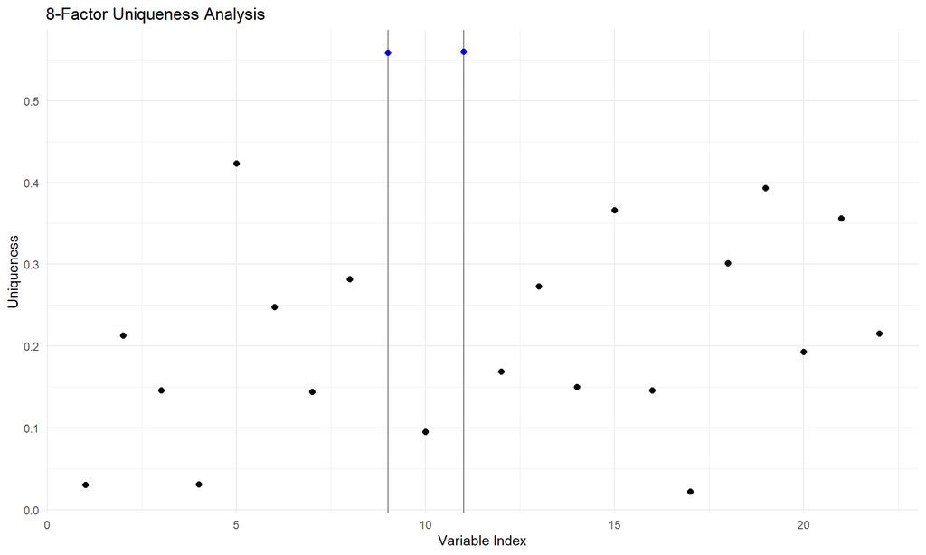

```r
FA8_Unq <- factanal(lafayette_122, factors = 8, rotation = 'varimax')

# Create a data frame with the diagonal values and their indices
df <- data.frame(values = FA8_Unq$uniquenesses, index = 1:22)

# Plot the diagonal values using ggplot2
ggplot(df, aes(x = index, y = values)) +
  geom_point(size = 2, color = ifelse(df$values > 0.45, "blue", "black")) +
  geom_vline(xintercept = 9,lwd = .05,color = "black") +
  geom_vline(xintercept = 11,lwd = .05,color = "black") +
  scale_x_continuous(name = "Variable Index") +
  scale_y_continuous(name = "Uniqueness") +
  ggtitle("8-Factor Uniqueness Analysis") +
  theme_minimal()
```

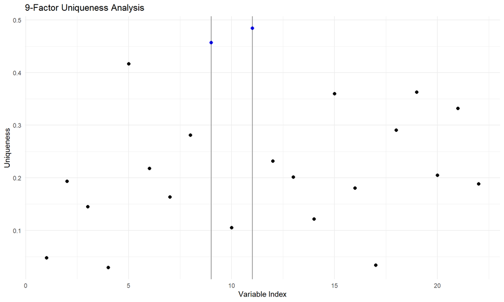

```r
FA9_Unq <- factanal(lafayette_122, factors = 9, rotation = 'varimax')

# Create a data frame with the diagonal values and their indices
df <- data.frame(values = FA9_Unq$uniquenesses, index = 1:22)

# Plot the diagonal values using ggplot2
ggplot(df, aes(x = index, y = values)) +
  geom_point(size = 2, color = ifelse(df$values > 0.45, "blue", "black")) +
  geom_vline(xintercept = 9,lwd = .05,color = "black") +
  geom_vline(xintercept = 11,lwd = .05,color = "black") +
  scale_x_continuous(name = "Variable Index") +
  scale_y_continuous(name = "Uniqueness") +
  ggtitle("9-Factor Uniqueness Analysis") +
  theme_minimal()
```

In factor analysis, it is important to understand the extent of each variable as it relates to the underlying constructs represented by the factors. When these unique values are high, it suggests that the variable may not be well equipped by the proposed factors. In the scenarios, $Im9$ and $Im11$ are higher than all the other questions. This means they are less relevant and should continue to be on the watch list.

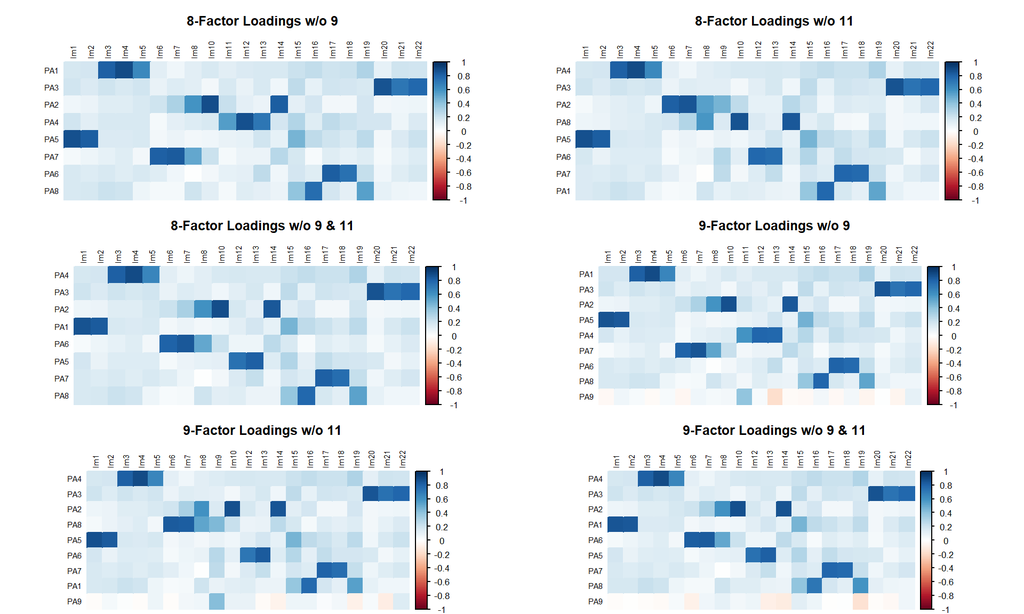

```r
par(mfrow = c(3,2))
corrplot(t(FA_PAF_89$loadings), tl.cex = 0.7, tl.col = "black", number.cex = 0.8, method = 'color', title = "8-Factor Loadings w/o 9", mar = c(0, 1, 3, 0))

corrplot(t(FA_PAF_811$loadings), tl.cex = 0.7, tl.col = "black", number.cex = 0.8, method = 'color', title = "8-Factor Loadings w/o 11", mar = c(0, 1, 3, 0))

corrplot(t(FA_PAF_8911$loadings), tl.cex = 0.7, tl.col = "black", number.cex = 0.8, method = 'color', title = "8-Factor Loadings w/o 9 & 11", mar = c(0, 1, 3, 0))

corrplot(t(FA_RAF_99$loadings), tl.cex = 0.7, tl.col = "black", number.cex = 0.8, method = 'color', title = "9-Factor Loadings w/o 9", mar = c(0, 1, 3, 0))

corrplot(t(FA_RAF_911$loadings), tl.cex = 0.7, tl.col = "black", number.cex = 0.8, method = 'color', title = "9-Factor Loadings w/o 11", mar = c(0, 1, 3, 0))

corrplot(t(FA_PAF_9911$loadings), tl.cex = 0.7, tl.col = "black", number.cex = 0.8, method = 'color', title = "9-Factor Loadings w/o 9 & 11", mar = c(0, 1, 3, 0))
```

```r
par(mfrow = c(1,1))
```

Principal Axis Factoring has been run on for the six models and we observe the loading matrix here as a correlation plot. The first model has 8-factors without question 9 since it had a high MSA diagonal and by its standalone nature when looking at the blue boxes within the first correlation matrix. Within all the factors, the loadings appear to be relatively high with only $Im15$ possibly being loaded lower in multiple factors. Therefore, $Im15$ will be added to the watch list. The second model looks at 8-factors without question 11 since the MSA diagonal was once again higher than all other questions and its lower communality. Now, it appears that $Im9$ follows suit with $Im15$ and is loaded in multiple factors. The third model with 8-factors but now excluding questions 9 and 11, which shows how $Im15$ is still problematic. Out of the three 8-factor models, 8-factor without $Im9$ has the lowest “BIC”, 8-factor without $Im9$ an $Im11$ has the lowest “rms”, and best “fit” and “TLI”.

```r
print(FA_RAF_99$loadings, cutoff = 0.4, sort = TRUE)
```

```
##
## Loadings:
##      PA1    PA3    PA2    PA5    PA4    PA7    PA6    PA8    PA9
## Im3   0.816
## Im4   0.896
## Im5   0.651
## Im20         0.857
## Im21         0.736
## Im22         0.788
## Im8                 0.599                0.520
## Im10                0.872
## Im14                0.850
## Im1                        0.865
## Im2                        0.841
## Im11                              0.591
## Im12                              0.794
## Im13                              0.784
## Im6                                      0.803
## Im7                                      0.854
## Im17                                            0.808
## Im18                                            0.770
## Im16                                                   0.792
## Im19                                                   0.528
## Im15                       0.470
##
##                  PA1   PA3   PA2   PA5   PA4   PA7   PA6   PA8   PA9
## SS loadings    2.507 2.366 2.241 2.128 2.063 1.933 1.651 1.355 0.232
## Proportion Var 0.119 0.113 0.107 0.101 0.098 0.092 0.079 0.065 0.011
## Cumulative Var 0.119 0.232 0.339 0.440 0.538 0.630 0.709 0.774 0.785
```

```r
print(FA_RAF_911$loadings, cutoff = 0.4, sort = TRUE)
```

```
##
## Loadings:
##      PA4    PA3    PA2    PA8    PA5    PA6    PA7    PA1    PA9
## Im3   0.815
## Im4   0.894
## Im5   0.655
## Im20         0.851
## Im21         0.744
## Im22         0.792
## Im8                 0.601  0.521
## Im10                0.878
## Im14                0.854
## Im6                        0.835
## Im7                        0.824
## Im1                               0.871
## Im2                               0.835
## Im12                                     0.730
## Im13                                     0.834
## Im17                                            0.808
## Im18                                            0.765
## Im16                                                   0.770
## Im19                                                   0.549
## Im9                        0.446                              0.428
## Im15                              0.469
##
##                  PA4   PA3   PA2   PA8   PA5   PA6   PA7   PA1   PA9
## SS loadings    2.509 2.364 2.255 2.156 2.128 1.723 1.691 1.359 0.275
## Proportion Var 0.119 0.113 0.107 0.103 0.101 0.082 0.081 0.065 0.013
## Cumulative Var 0.119 0.232 0.339 0.442 0.543 0.625 0.706 0.771 0.784
```

```r
print(FA_PAF_9911$loadings, cutoff = 0.4, sort = TRUE)
```

```
##
## Loadings:
##      PA4    PA3    PA2    PA1    PA6    PA5    PA7    PA8    PA9
## Im3   0.815
## Im4   0.891
## Im5   0.655
## Im20         0.864
## Im21         0.733
## Im22         0.789
## Im8                 0.607         0.515
## Im10                0.873
## Im14                0.863
## Im1                        0.859
## Im2                        0.842
## Im6                               0.820
## Im7                               0.835
## Im12                                     0.747
## Im13                                     0.818
## Im17                                            0.798
## Im18                                            0.779
## Im16                                                   0.725
## Im19                                                   0.599
## Im15                       0.469
##
##                  PA4   PA3   PA2   PA1   PA6   PA5   PA7   PA8   PA9
## SS loadings    2.479 2.363 2.254 2.101 1.910 1.651 1.636 1.365 0.099
## Proportion Var 0.124 0.118 0.113 0.105 0.095 0.083 0.082 0.068 0.005
## Cumulative Var 0.124 0.242 0.355 0.460 0.555 0.638 0.720 0.788 0.793
```

A 9-factor solution is not optimal because 9-factor without $Im9$ has nothing loaded in PA9, and this occurs similarly when both questions are removed. For 9-factor without $Im11$, PA9 includes $Im9$, but it has a very low loading of 0.428 and is split within PA8 in a similar manner. Therefore, we do not continue exploring 9-factors.

```r
print(FA_PAF_89$loadings, cutoff = 0.4, sort = TRUE)
```

```
##
## Loadings:
##      PA1   PA3   PA2   PA4   PA5   PA7   PA6   PA8
## Im3  0.812
## Im4  0.893
## Im5  0.650
## Im20       0.860
## Im21       0.728
## Im22       0.786
## Im8              0.599             0.520
## Im10             0.887
## Im14             0.823
## Im11                   0.560
## Im12                   0.878
## Im13                   0.721
## Im1                          0.870
## Im2                          0.828
## Im6                                0.816
## Im7                                0.838
## Im17                                     0.824
## Im18                                     0.747
## Im16                                           0.765
## Im19                                           0.546
## Im15                         0.467
##
##                  PA1   PA3   PA2   PA4   PA5   PA7   PA6   PA8
## SS loadings    2.471 2.346 2.213 2.150 2.101 1.928 1.634 1.354
## Proportion Var 0.118 0.112 0.105 0.102 0.100 0.092 0.078 0.064
## Cumulative Var 0.118 0.229 0.335 0.437 0.537 0.629 0.707 0.771
```

```r
print(FA_PAF_811$loadings, cutoff = 0.4, sort = TRUE)
```

```
##
## Loadings:
##      PA4   PA3   PA2   PA8   PA5   PA6   PA7   PA1
## Im3  0.816
## Im4  0.893
## Im5  0.650
## Im20       0.863
## Im21       0.734
## Im22       0.783
## Im6              0.817
## Im7              0.852
## Im8              0.543 0.589
## Im10                   0.865
## Im14                   0.847
## Im1                          0.873
## Im2                          0.830
## Im12                               0.789
## Im13                               0.768
## Im17                                     0.800
## Im18                                     0.772
## Im16                                           0.782
## Im19                                           0.529
## Im9              0.467
## Im15                         0.468
##
##                  PA4   PA3   PA2   PA8   PA5   PA6   PA7   PA1
## SS loadings    2.497 2.360 2.281 2.171 2.122 1.717 1.688 1.349
## Proportion Var 0.119 0.112 0.109 0.103 0.101 0.082 0.080 0.064
## Cumulative Var 0.119 0.231 0.340 0.443 0.544 0.626 0.707 0.771
```

```r
print(FA_PAF_8911$loadings, cutoff = 0.4, sort = TRUE)
```

```
##
## Loadings:
##      PA4   PA3   PA2   PA1   PA6   PA5   PA7   PA8
## Im3  0.816
## Im4  0.894
## Im5  0.652
## Im20       0.865
## Im21       0.731
## Im22       0.787
## Im8              0.605       0.518
## Im10             0.889
## Im14             0.840
## Im1                    0.866
## Im2                    0.837
## Im6                          0.802
## Im7                          0.848
## Im12                               0.747
## Im13                               0.812
## Im17                                     0.811
## Im18                                     0.765
## Im16                                           0.781
## Im19                                           0.533
## Im15                   0.468
##
##                  PA4   PA3   PA2   PA1   PA6   PA5   PA7   PA8
## SS loadings    2.487 2.360 2.239 2.109 1.913 1.649 1.640 1.350
## Proportion Var 0.124 0.118 0.112 0.105 0.096 0.082 0.082 0.067
## Cumulative Var 0.124 0.242 0.354 0.460 0.555 0.638 0.720 0.787
```

The loadings are an important estimation when it comes to analyzing the correlation between each observed variable and the proposed factors. They can be thought of as weights. When the weight is higher, that indicates the question is associated with the factor. Ideally, the weights of 0.7 or above would be considered good loadings. Therefore, it is important to identify those that may not be as highly loaded as they could be problematic.

Between the first two models, 8-factors without $Im9$ and 8-factors without $Im11$ have the same cumulative variance at 77.1%, and $Im15$ has the lowest loading. When $Im9$ is excluded, in PA8, $Im19$ has a lower loading of 0.546, $Im11$ is with PA4 at a loading of 0.560, and $Im8$ is basically split into two loadings. $Im8$, $Im11$, $Im15$, and $Im19$ should be on the watch list. In the second model, now $Im9$ has the lowest loading, followed by $Im15$, $Im19$, and $Im8$’s split has a smaller gap as they approach 50% more.

When eliminating both $Im9$ and $Im11$, the total variance increases to 78.7%. In addition, $Im8$ slightly improves to show that but still has higher loadings in both that make it harder to determine where it would fit. $Im15$ continues to be the lowest loading, while $Im19$’s weight improves from the second model, but worsens from the first. We will look at the communalities of these three models to determine next steps.

```r
sort(FA_PAF_89$communality)
```

```
##      Im11       Im5      Im19      Im21      Im15      Im13       Im8      Im18
## 0.4303298 0.5768518 0.6242481 0.6414685 0.6439185 0.7035537 0.7224451 0.7391413
##       Im6      Im22      Im16      Im20       Im2      Im14       Im7       Im3
## 0.7546850 0.7845445 0.7943053 0.8099533 0.8225340 0.8384396 0.8551511 0.8555887
##      Im12      Im10      Im17       Im1       Im4
## 0.8663999 0.9153327 0.9225160 0.9246863 0.9698816
```

The communality of a variable shows the contribution of all factors together in explaining the variance of this variable. $Im11$ has the lowest communality by far. In addition, $Im5$ pops into purview, but the loading in the three models continuously was over 0.6, and will not be added to the watch list. $Im19$ has a lower communality than $Im15$ too.

```r
sort(FA_PAF_811$communality)
```

```
##       Im9       Im5      Im19      Im21      Im15       Im8       Im6      Im12
## 0.4460684 0.5754713 0.6120917 0.6468686 0.6474172 0.7241180 0.7432552 0.7523395
##      Im18      Im13      Im22      Im20      Im16       Im2       Im7       Im3
## 0.7702650 0.7801691 0.7822372 0.8096638 0.8187269 0.8236583 0.8567024 0.8571063
##      Im14      Im10      Im17       Im1       Im4
## 0.8675380 0.8866330 0.8903819 0.9272940 0.9680242
```

When removing $Im11$, the lowest communality is $Im9$, and next in line is once again, $Im5$ and $Im19$.

```r
sort(FA_PAF_8911$communality)
```

```
##       Im5      Im19      Im21      Im15      Im12       Im8       Im6      Im18
## 0.5763930 0.6159849 0.6432490 0.6453553 0.6949377 0.7208790 0.7364211 0.7575349
##      Im22      Im20      Im16       Im2      Im13      Im14       Im3       Im7
## 0.7817508 0.8111027 0.8169967 0.8338276 0.8399195 0.8509792 0.8564647 0.8697177
##      Im17      Im10       Im1       Im4
## 0.9028525 0.9064084 0.9168156 0.9688954
```

In the third model, $Im11$ an $Im9$ are removed. $Im5$ has the smallest communality, but the gap between $Im5$ and $Im19$ do not cause concern.

Since $Im5$ has a decently high loading despite the lower communality between all three models, we will not move forward with exploring to remove this variable since logically, it makes sense that $Im3$, $Im4$, and $Im5$ stay within one factor. But, there are three other questions that remain on the watch list 8, 15, and 19. Now, we rerun these model with different combinations of removing images 8, 9, 11, 15, and 19 with 8-factors.

```r
FA8_9 <- fa(lafayette_122[, -c(9)], nfactors = 8, rotate = "varimax", fm = "pa")
FA8_89 <- fa(lafayette_122[, -c(8, 9)], nfactors = 8, rotate = "varimax", fm = "pa")
FA8_911 <- fa(lafayette_122[, -c(9, 11)], nfactors = 8, rotate = "varimax", fm = "pa")
FA8_915 <- fa(lafayette_122[, -c(9, 15)], nfactors = 8, rotate = "varimax", fm = "pa")
FA8_919 <- fa(lafayette_122[, -c(9, 19)], nfactors = 8, rotate = "varimax", fm = "pa")
FA8_91115 <- fa(lafayette_122[, -c(9, 11, 15)], nfactors = 8, rotate = "varimax", fm = "pa")
FA8_91119 <- fa(lafayette_122[, -c(9, 11, 19)], nfactors = 8, rotate = "varimax", fm = "pa")
FA8_8915 <- fa(lafayette_122[, -c(8, 9, 15)], nfactors = 8, rotate = "varimax", fm = "pa")
FA8_8919 <- fa(lafayette_122[, -c(8, 9, 19)], nfactors = 8, rotate = "varimax", fm = "pa")
```

```r
print(FA8_9$loadings, cutoff = 0.4, sort = TRUE)
```

```
##
## Loadings:
##      PA1   PA3   PA2   PA4   PA5   PA7   PA6   PA8
## Im3  0.812
## Im4  0.893
## Im5  0.650
## Im20       0.860
## Im21       0.728
## Im22       0.786
## Im8              0.599             0.520
## Im10             0.887
## Im14             0.823
## Im11                   0.560
## Im12                   0.878
## Im13                   0.721
## Im1                          0.870
## Im2                          0.828
## Im6                                0.816
## Im7                                0.838
## Im17                                     0.824
## Im18                                     0.747
## Im16                                           0.765
## Im19                                           0.546
## Im15                         0.467
##
##                  PA1   PA3   PA2   PA4   PA5   PA7   PA6   PA8
## SS loadings    2.471 2.346 2.213 2.150 2.101 1.928 1.634 1.354
## Proportion Var 0.118 0.112 0.105 0.102 0.100 0.092 0.078 0.064
## Cumulative Var 0.118 0.229 0.335 0.437 0.537 0.629 0.707 0.771
```

```r
print(FA8_89$loadings, cutoff = 0.4, sort = TRUE)
```

```
##
## Loadings:
##      PA1   PA3   PA4   PA5   PA2   PA7   PA6   PA8
## Im3  0.812
## Im4  0.894
## Im5  0.651
## Im20       0.860
## Im21       0.729
## Im22       0.787
## Im11             0.562
## Im12             0.880
## Im13             0.721
## Im1                    0.881
## Im2                    0.816
## Im10                         0.917
## Im14                         0.778
## Im6                                0.888
## Im7                                0.779
## Im17                                     0.856
## Im18                                     0.720
## Im16                                           0.771
## Im19                                           0.558
## Im15                   0.466
##
##                  PA1   PA3   PA4   PA5   PA2   PA7   PA6   PA8
## SS loadings    2.464 2.339 2.152 2.089 1.776 1.692 1.641 1.369
## Proportion Var 0.123 0.117 0.108 0.104 0.089 0.085 0.082 0.068
## Cumulative Var 0.123 0.240 0.348 0.452 0.541 0.626 0.708 0.776
```

```r
print(FA8_911$loadings, cutoff = 0.4, sort = TRUE)
```

```
##
## Loadings:
##      PA4   PA3   PA2   PA1   PA6   PA5   PA7   PA8
## Im3  0.816
## Im4  0.894
## Im5  0.652
## Im20       0.865
## Im21       0.731
## Im22       0.787
## Im8              0.605       0.518
## Im10             0.889
## Im14             0.840
## Im1                    0.866
## Im2                    0.837
## Im6                          0.802
## Im7                          0.848
## Im12                               0.747
## Im13                               0.812
## Im17                                     0.811
## Im18                                     0.765
## Im16                                           0.781
## Im19                                           0.533
## Im15                   0.468
##
##                  PA4   PA3   PA2   PA1   PA6   PA5   PA7   PA8
## SS loadings    2.487 2.360 2.239 2.109 1.913 1.649 1.640 1.350
## Proportion Var 0.124 0.118 0.112 0.105 0.096 0.082 0.082 0.067
## Cumulative Var 0.124 0.242 0.354 0.460 0.555 0.638 0.720 0.787
```

```r
print(FA8_915$loadings, cutoff = 0.4, sort = TRUE)
```

```
##
## Loadings:
##      PA1   PA3   PA2   PA4   PA7   PA5   PA6   PA8
## Im3  0.814
## Im4  0.893
## Im5  0.651
## Im20       0.865
## Im21       0.728
## Im22       0.787
## Im8              0.603       0.516
## Im10             0.893
## Im14             0.819
## Im11                   0.563
## Im12                   0.880
## Im13                   0.719
## Im6                          0.820
## Im7                          0.835
## Im1                                0.881
## Im2                                0.802
## Im17                                     0.837
## Im18                                     0.739
## Im16                                           0.722
## Im19                                           0.581
##
##                  PA1   PA3   PA2   PA4   PA7   PA5   PA6   PA8
## SS loadings    2.447 2.305 2.210 2.083 1.900 1.798 1.621 1.171
## Proportion Var 0.122 0.115 0.111 0.104 0.095 0.090 0.081 0.059
## Cumulative Var 0.122 0.238 0.348 0.452 0.547 0.637 0.718 0.777
```

```r
print(FA8_919$loadings, cutoff = 0.4, sort = TRUE)
```

```
##
## Loadings:
##      PA1   PA3   PA2   PA5   PA4   PA7   PA6   PA8
## Im3  0.820
## Im4  0.901
## Im5  0.652
## Im20       0.860
## Im21       0.730
## Im22       0.787
## Im8              0.608             0.518
## Im10             0.888
## Im14             0.830
## Im1                    0.879
## Im2                    0.836
## Im11                         0.560
## Im12                         0.878
## Im13                         0.724
## Im6                                0.816
## Im7                                0.837
## Im17                                     0.827
## Im18                                     0.752
## Im16                                           0.588
## Im15                   0.488                   0.400
##
##                  PA1   PA3   PA2   PA5   PA4   PA7   PA6   PA8
## SS loadings    2.465 2.329 2.226 2.136 2.133 1.907 1.618 0.656
## Proportion Var 0.123 0.116 0.111 0.107 0.107 0.095 0.081 0.033
## Cumulative Var 0.123 0.240 0.351 0.458 0.564 0.660 0.741 0.773
```

```r
print(FA8_91115$loadings, cutoff = 0.4, sort = TRUE)
```

```
##
## Loadings:
##      PA1   PA3   PA2   PA6   PA5   PA4   PA7   PA8
## Im3  0.819
## Im4  0.895
## Im5  0.653
## Im20       0.870
## Im21       0.730
## Im22       0.788
## Im8              0.608 0.516
## Im10             0.895
## Im14             0.834
## Im6                    0.807
## Im7                    0.845
## Im1                          0.885
## Im2                          0.803
## Im17                               0.820
## Im18                               0.760
## Im12                                     0.705
## Im13                                     0.861
## Im16                                           0.757
## Im19                                           0.553
##
##                  PA1   PA3   PA2   PA6   PA5   PA4   PA7   PA8
## SS loadings    2.465 2.315 2.235 1.890 1.808 1.623 1.593 1.179
## Proportion Var 0.130 0.122 0.118 0.099 0.095 0.085 0.084 0.062
## Cumulative Var 0.130 0.252 0.369 0.469 0.564 0.649 0.733 0.795
```

```r
print(FA8_91119$loadings, cutoff = 0.4, sort = TRUE)
```

```
##
## Loadings:
##      PA4   PA3   PA2   PA1   PA6   PA5   PA7   PA8
## Im3  0.824
## Im4  0.902
## Im5  0.654
## Im20       0.864
## Im21       0.733
## Im22       0.788
## Im8              0.612       0.518
## Im10             0.886
## Im14             0.849
## Im1                    0.872
## Im2                    0.846
## Im6                          0.804
## Im7                          0.847
## Im12                               0.740
## Im13                               0.824
## Im17                                     0.808
## Im18                                     0.776
## Im16                                           0.589
## Im15                   0.486
##
##                  PA4   PA3   PA2   PA1   PA6   PA5   PA7   PA8
## SS loadings    2.476 2.342 2.246 2.136 1.896 1.637 1.621 0.661
## Proportion Var 0.130 0.123 0.118 0.112 0.100 0.086 0.085 0.035
## Cumulative Var 0.130 0.254 0.372 0.484 0.584 0.670 0.755 0.790
```

```r
print(FA8_8915$loadings, cutoff = 0.4, sort = TRUE)
```

```
##
## Loadings:
##      PA1   PA3   PA4   PA5   PA2   PA7   PA6   PA8
## Im3  0.813
## Im4  0.892
## Im5  0.653
## Im20       0.864
## Im21       0.728
## Im22       0.789
## Im11             0.566
## Im12             0.881
## Im13             0.720
## Im1                    0.896
## Im2                    0.788
## Im10                         0.936
## Im14                         0.762
## Im6                                0.911
## Im7                                0.761
## Im17                                     0.855
## Im18                                     0.723
## Im16                                           0.651
## Im19                                           0.664
##
##                  PA1   PA3   PA4   PA5   PA2   PA7   PA6   PA8
## SS loadings    2.427 2.296 2.083 1.791 1.778 1.682 1.613 1.193
## Proportion Var 0.128 0.121 0.110 0.094 0.094 0.089 0.085 0.063
## Cumulative Var 0.128 0.249 0.358 0.453 0.546 0.635 0.720 0.782
```

```r
print(FA8_8919$loadings, cutoff = 0.4, sort = TRUE)
```

```
##
## Loadings:
##      PA1   PA3   PA4   PA5   PA2   PA7   PA6   PA8
## Im3  0.821
## Im4  0.903
## Im5  0.655
## Im20       0.859
## Im21       0.730
## Im22       0.788
## Im11             0.563
## Im12             0.880
## Im13             0.723
## Im1                    0.905
## Im2                    0.811
## Im10                         0.932
## Im14                         0.772
## Im6                                0.888
## Im7                                0.781
## Im17                                     0.855
## Im18                                     0.729
## Im16                                           0.586
## Im15                   0.483                   0.413
##
##                  PA1   PA3   PA4   PA5   PA2   PA7   PA6   PA8
## SS loadings    2.465 2.322 2.136 2.124 1.785 1.683 1.627 0.647
## Proportion Var 0.130 0.122 0.112 0.112 0.094 0.089 0.086 0.034
## Cumulative Var 0.130 0.252 0.364 0.476 0.570 0.659 0.744 0.778
```

It can be confirmed that once $Im9$ is removed, the cumulative variance increases within the models above and the loadings slightly increase too. The next question is whether to remove the other watch list images, $Im8$, $Im11$, $Im15$, or $Im19$. The model that explains the most at 79.5% is one that excludes images 9, 11, and 15, but the issue there continues to be with $Im8$. We check one more loading matrix without $Im8$, $Im9$, $Im11$, and $Im15$.

```r
FA8_891115 <- fa(lafayette_122[, -c(8, 9, 11, 15)], nfactors = 8, rotate = "varimax", fm = "pa")
```

```
## maximum iteration exceeded
```

```r
print(FA8_891115$loadings, cutoff = 0.4, sort = TRUE)
```

```
##
## Loadings:
##      PA1   PA3   PA5   PA2   PA6   PA4   PA7   PA8
## Im3  0.816
## Im4  0.894
## Im5  0.655
## Im20       0.869
## Im21       0.731
## Im22       0.790
## Im1              0.896
## Im2              0.791
## Im10                   0.931
## Im14                   0.781
## Im6                          0.885
## Im7                          0.782
## Im17                               0.828
## Im18                               0.751
## Im12                                     0.706
## Im13                                     0.862
## Im16                                           0.696
## Im19                                           0.622
##
##                  PA1   PA3   PA5   PA2   PA6   PA4   PA7   PA8
## SS loadings    2.439 2.306 1.797 1.789 1.667 1.611 1.594 1.193
## Proportion Var 0.135 0.128 0.100 0.099 0.093 0.089 0.089 0.066
## Cumulative Var 0.135 0.264 0.363 0.463 0.555 0.645 0.733 0.800
```

All questions seem to be highly loaded within one factor and overall, has a total variance of 80.0%. When compared to a similiar model but the one that includes $Im11$, the variance explained decreases to 78.2%.

```r
sort(FA8_9$communality)
```

```
##      Im11       Im5      Im19      Im21      Im15      Im13       Im8      Im18
## 0.4303298 0.5768518 0.6242481 0.6414685 0.6439185 0.7035537 0.7224451 0.7391413
##       Im6      Im22      Im16      Im20       Im2      Im14       Im7       Im3
## 0.7546850 0.7845445 0.7943053 0.8099533 0.8225340 0.8384396 0.8551511 0.8555887
##      Im12      Im10      Im17       Im1       Im4
## 0.8663999 0.9153327 0.9225160 0.9246863 0.9698816
```

```r
sort(FA8_911$communality)
```

```
##       Im5      Im19      Im21      Im15      Im12       Im8       Im6      Im18
## 0.5763930 0.6159849 0.6432490 0.6453553 0.6949377 0.7208790 0.7364211 0.7575349
##      Im22      Im20      Im16       Im2      Im13      Im14       Im3       Im7
## 0.7817508 0.8111027 0.8169967 0.8338276 0.8399195 0.8509792 0.8564647 0.8697177
##      Im17      Im10       Im1       Im4
## 0.9028525 0.9064084 0.9168156 0.9688954
```

```r
sort(FA8_915$communality)
```

```
##      Im11       Im5      Im21      Im19      Im13       Im8      Im18      Im16
## 0.4332478 0.5776258 0.6386323 0.6561694 0.6976318 0.7197091 0.7270328 0.7373603
##       Im6      Im22       Im2      Im20      Im14       Im7       Im3      Im12
## 0.7611128 0.7831167 0.7964771 0.8169705 0.8317489 0.8515567 0.8553316 0.8671795
##      Im10      Im17       Im1       Im4
## 0.9223828 0.9372361 0.9550466 0.9694173
```

```r
sort(FA8_919$communality)
```

```
##      Im11       Im5      Im16      Im21      Im15      Im13       Im8      Im18
## 0.4301867 0.5782208 0.6406485 0.6420547 0.6836965 0.7041447 0.7336688 0.7425901
##       Im6      Im22      Im20       Im2      Im14       Im3       Im7      Im12
## 0.7562690 0.7846811 0.8070295 0.8217971 0.8436469 0.8545315 0.8548538 0.8655410
##      Im10      Im17       Im1       Im4
## 0.9106233 0.9196618 0.9249444 0.9705018
```

```r
sort(FA8_91119$communality)
```

```
##       Im5      Im16      Im21      Im12      Im15       Im8       Im6      Im18
## 0.5777897 0.6400406 0.6443032 0.6861192 0.6864314 0.7327326 0.7396569 0.7686560
##      Im22      Im20       Im2      Im13       Im3      Im14       Im7      Im17
## 0.7819445 0.8079317 0.8352949 0.8550410 0.8557974 0.8609063 0.8677959 0.8913906
##      Im10       Im1       Im4
## 0.8982144 0.9145963 0.9688731
```

```r
sort(FA8_91115$communality)
```

```
##       Im5      Im19      Im12      Im21       Im8       Im6      Im18      Im22
## 0.5769364 0.6335182 0.6399481 0.6402927 0.7181974 0.7423870 0.7491642 0.7799953
##      Im16       Im2      Im20      Im14       Im3       Im7      Im13      Im17
## 0.7837527 0.7959598 0.8194297 0.8428276 0.8562857 0.8655594 0.9099175 0.9118600
##      Im10       Im1       Im4
## 0.9143553 0.9590980 0.9684263
```

```r
sort(FA8_8915$communality)
```

```
##      Im11       Im5      Im21      Im16      Im13      Im18      Im19       Im7
## 0.4329273 0.5793745 0.6382830 0.6436939 0.6968226 0.7078105 0.7275401 0.7395077
##      Im14       Im2      Im22      Im20       Im3      Im12       Im6      Im17
## 0.7737207 0.7782390 0.7854382 0.8153635 0.8550184 0.8670082 0.9011484 0.9643328
##       Im4       Im1      Im10
## 0.9682718 0.9792472 1.0096155
```

```r
sort(FA8_891115$communality)
```

```
##       Im5      Im12      Im21      Im19      Im16      Im18       Im7       Im2
## 0.5796092 0.6394938 0.6399788 0.6856562 0.6938570 0.7386726 0.7657928 0.7810844
##      Im22      Im14      Im20       Im3       Im6      Im13      Im17       Im4
## 0.7819387 0.7869685 0.8180959 0.8555484 0.8567127 0.9097877 0.9245597 0.9675214
##       Im1      Im10
## 0.9788646 0.9908097
```